# Maps, Coordinate Reference Systems and Visualising Geographic Data with mapmisc

The *mapmisc* package provides functions for visualising geospatial data, including fetching background map layers, producing colour scales and legends, and adding scale bars and orientation arrows to plots. Background maps are returned in the coordinate reference system of the dataset supplied, and inset maps and direction arrows reflect the map projection being plotted. This is a “light weight” package having an emphasis on simplicity and ease of use.

Patrick Brown (Cancer Care Ontario)  
2016-07-28

## 1 Introduction

R has extensive facilities for managing, manipulating, and visualising spatial data, with the [*sp*](https://CRAN.R-project.org/package=sp) (Pebesma and Bivand 2005) and [*raster*](https://CRAN.R-project.org/package=raster) (Hijmans 2015b) packages providing a set of object classes and core functions which numerous other packages have built on. It is fairly straightforward to import spatial data of a variety of types and from a range of sources including: images for map backgrounds; high-resolution pixel grids of surface elevation; and polygons of administrative region boundaries. Large volumes of such data are available for download from sites such as worldgrids.org, gadm.org, and nhgis.org, and map images are freely available from [OpenStreetMap.org](http://openstreetmap.org) and other online maps. The first issue often encountered after downloading and importing spatial data is reconciling different coordinate reference systems (CRS’s, or map projections). Most repositories of spatial data provide longitude-latitude coordinates, although single-country data sources often use a country-specific map projection (i.e. the UK’s Ordinance Survey National Grid) and online maps mostly use the Web Mercator projection. The suitability of a particular map projection will depend on the geographic region being considered and the specific problem at hand.

The [*mapmisc*](https://CRAN.R-project.org/package=mapmisc) package (Brown 2016) provides tools for working with projected data which cover the following four areas:

- producing maps with projected data, including scale bars, background images, and inset maps;
- defining and using equal-area map projections for displaying the entire globe;
- creating optimal region-specific map projections where distances are preserved; and
- mapping with colour scales for continuous and categorical data.

This paper will cover each of these points in turn, working through examples and briefly describing the operations by the functions in the *mapmisc* package. An emphasis is given to tidy, intuitive, and reproducible code accessible for students and non-specialists.

### 1.1 Installation and related packages

The two most important packages required for using spatial data in R are the *sp* and *raster* packages, which provide tools and classes for vector data (spatial data on a continuous domain) and raster data (defined on a pixelated grid) respectively. Installing *mapmisc* with `install.packages("mapmisc")` or by using a menu item on a GUI will install *sp* and *raster* if they are not already present. A third important spatial package is [*rgdal*](https://CRAN.R-project.org/package=rgdal) (Bivand et al. 2016), which provides methods for re-projecting coordinates and importing spatial data in various file formats. The Geographic Data Abstraction Language (GDAL) underlies *rgdal*, aligning with R’s UNIX-like philosophy of combining separate and specialised pieces of software. On most UNIX-based systems, the GDAL and proj4 software must be installed separately prior to installing *rgdal*. All versions of Windows and most versions of MacOS have binary versions of *rgdal* which include the GDAL and proj4 binaries, and *rgdal* can be installed in the same manner as any other R package.

Additional packages used by *mapmisc* are: [*RColorBrewer*](https://CRAN.R-project.org/package=RColorBrewer) (Neuwirth 2014), [*classInt*](https://CRAN.R-project.org/package=classInt) (Bivand 2015), [*rgeos*](https://CRAN.R-project.org/package=rgeos) (Bivand and Rundel 2016), and [*geosphere*](https://CRAN.R-project.org/package=geosphere) (Hijmans 2015a). These four packages and *rgdal* are not always installed automatically with *mapmisc*, as they are marked as “suggested” packages with *mapmisc* being usable with a reduced level of functionality without them. Three further packages necessary for reproducing the examples in this paper are [*dismo*](https://CRAN.R-project.org/package=dismo) (Hijmans et al. 2016), [*maptools*](https://CRAN.R-project.org/package=maptools) (Bivand and Lewin-Koh 2016), and [*R.utils*](https://CRAN.R-project.org/package=R.utils) (Bengtsson 2016).

Loading the packages with

```r
library("rgdal")
library("mapmisc")
```

also makes *sp* and *raster* available. The remaining packages do not need to be loaded explicitly and will be called by *mapmisc* as needed.

### 1.2 Getting started with spatial data in R

The `getData` function provided by *raster* is able to download a number of useful and interesting spatial datasets. The coastline and borders of Finland can be fetched with

```r
finland <- raster::getData("GADM", country = "FIN", level = 0)
```

The object `finland` is a “SpatialPolygonsDataFrame”, and Bivand et al. (2013) contains a wealth of information on working with objects of this type. The command

```r
plot(finland, axes = TRUE)
```

produces the plot in Figure 1a.

The choice of Finland as an example is due to its being far from the equator, and a useful contrast on the other side of the world is New Zealand. The coastline of New Zealand, obtained with

```r
nz <- raster::getData("GADM", country = "NZL", level = 0)
```

includes a number of small outlying islands. The spatial extent of the `nz` object,

```r
raster::extent(nz)
```

```r
## class       : Extent
## xmin        : -179
## xmax        : 179
## ymin        : -52.6
## ymax        : -29.2
```

spans the entire globe in the $x$-direction since New Zealand has islands on both sides of the $180^{\circ}$ meridian. Finding an appropriate axis limit through trial and error brings one to

```r
plot(nz, xlim = c(167, 178), axes = TRUE)
```

and the map in Figure 1b.

The outlying islands can be removed from the `nz` object using the `crop` function in the *raster* package, which in turn calls *rgeos*. Using the `locator` function and a few iterations of trial and error leads to the discovery that a region spanning 160 to 180 degrees longitude and $-47$ to $-30$ degrees latitude boxes in the main islands of New Zealand fairly tightly. The parts of New Zealand contained within this box can be extracted by creating an `extent` object and passing it to `crop`.

```r
nzClip <- raster::crop(nz, extent(160, 180, -47, -30))
```

The `finland` and `nzClip` objects will be used in the mapping examples which follow.

## 2 Working with map projections

This section covers mapping projected data and defining customised map projections. Adding background images, scale bars, and inset maps to plots with the `map.new`, `openmap`, `scaleBar`, and `insetMap` functions is demonstrated in the production of Figure 2. Map projections suitable for displaying the entire globe are constructed with the `moll` function, and along with the `wrapPolys` function Figure 5 is made. Map projections where Euclidean distances from $x$-$y$ coordinates are useful approximations of shortest distances between points on the globe are obtained with the `omerc` function and used to produce Figure 7.

### 2.1 Spatial data with coordinate reference systems

The spatial coordinates in Figures 1a and 1b are angles of longitudes and latitudes; coordinates which would be equivalent to the two angles of the spherical coordinate system $(\rho, \theta, \phi)$ familiar to mathematicians were it not for the inconvenient fact that the Earth is not spherical. The Earth is rather an oblate spheroid, slightly “squashed” or pumpkin-shaped, and the angles of orientations of lines pointing directly “up” (with reference to the stars) and “down” (as defined by a plumb line pulled straight by gravity) differ. As a result, various types of long-lat coordinates are in use, with the World Geodesic System (WGS84) used by Global Positioning Systems being the most widespread. The European Petroleum Standards Group (EPSG) catalogue of Coordinate Reference Systems (or CRS’s) refers to this system by the code 4326, and this code can be used to create an R object of class “CRS” corresponding to the WGS84 system using the `CRS` function from the *sp* package.

```r
sp::CRS("+init=epsg:4326")
```

```r
## CRS arguments:
##  +init=epsg:4326 +proj=longlat +datum=WGS84 +no_defs +ellps=WGS84
## +towgs84=0,0,0
```

The syntax of `+argument=value` for specifying a CRS comes from the [PROJ.4 Cartographic Projections Library](https://github.com/OSGeo/proj.4/wiki), with `+proj=longlat` indicating coordinates are angles and `ellps=WGS84` specifying that the Earth is an ellipsoid with values of the major axis length, minor axis length, and flattening corresponding to the WGS84 specification.

The difficulty angular coordinates pose for interpreting maps or using spatial statistics is that Euclidean distance $\sqrt{x^2 + y^2}$ is not always a useful measure of the distance separating two points. The shortest route between two points on a sphere follows a Great Circle which divides the globe into two equal halves. The distance between two points along this path, the Great Circle distance (see Wikipedia 2015a), can be computed with a trigonometric formula as implemented in the `spDists` function in *sp*. Euclidean distance will be roughly proportional to Great Circle distance for two points near the equator and reasonably close to one another. In Finland and New Zealand, however, Euclidean distance will over-emphasise the east-west direction since one degree of longitude is a much shorter distance (in kilometres) than one degree of latitude. It is for this reason that Greenland appears larger than India on many maps even though the opposite is true. Most R packages which perform spatial analyses rely on Euclidean distance, including this author’s [*geostatsp*](https://CRAN.R-project.org/package=geostatsp) (Brown 2015), even though Great Circle distance would be straightforward to implement. Fitting a spatial model with *geostatsp* to data in long-lat coordinates from Finland might uncover directional effects with strong correlation in the east-west direction, which could well be an artefact arising from the over-estimation of east-west distances. The importance of transforming spherical coordinates to a coordinate system where the Euclidean distance is a reasonable approximation to the Great Circle distance should not be under-estimated.

Most countries have an “official” CRS which produces accurate Euclidean distances for specific areas of the globe, one of which is the [Finland Uniform Coordinate System](http://spatialreference.org/ref/epsg/2393) having EPSG code 2393. This projection is obtained in R by `CRS` with

```r
CRS("+init=epsg:2393")
```

```r
## CRS arguments:
##  +init=epsg:2393 +proj=tmerc +lat_0=0 +lon_0=27 +k=1 +x_0=3500000 +y_0=0
## +ellps=intl +towgs84=-96.062,-82.428,-121.753,4.801,0.345,-1.376,1.496
## +units=m +no_defs
```

This is a Transverse Mercator projection (`+proj=tmerc`) with $x$ and $y$ coordinates giving positions on a cylinder containing the earth. The entry `+lon_0=27` indicates that the cylinder touches the Earth along the $27^\circ$ meridian line. Provided two points are reasonably close to the $27^\circ$ meridian, Euclidean distance between their Finland Uniform Coordinates will be very close to the true distance between them. The map of Finland can be converted to this coordinate system using `spTransform` from *sp* and *rgdal* with

```r
finlandMerc <- spTransform(finland, CRS("+init=epsg:2393"))
```

Figure 1c is the result of plotting this object with `plot(finlandMerc, axes = TRUE)`. Notice the projected map has a wider base and narrower top than the long-lat map in Figure 1a. The coordinates in Figure 1c refer to an origin where the $27^\circ$ meridian intersects the equator, with the `+x_0=` argument above indicating that 3,500km are added to the $x$ coordinates.

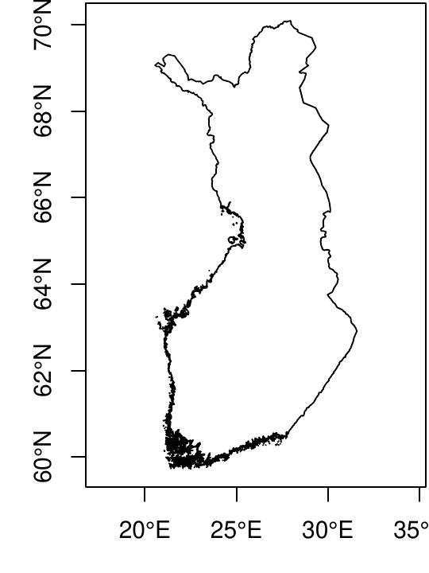

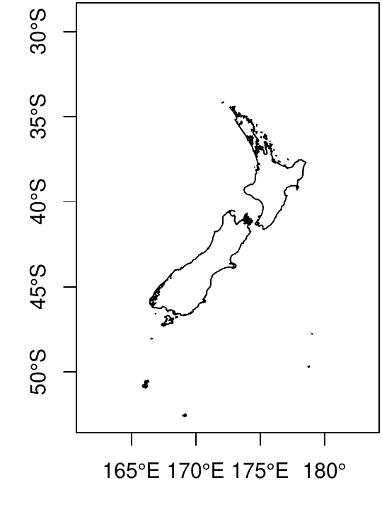

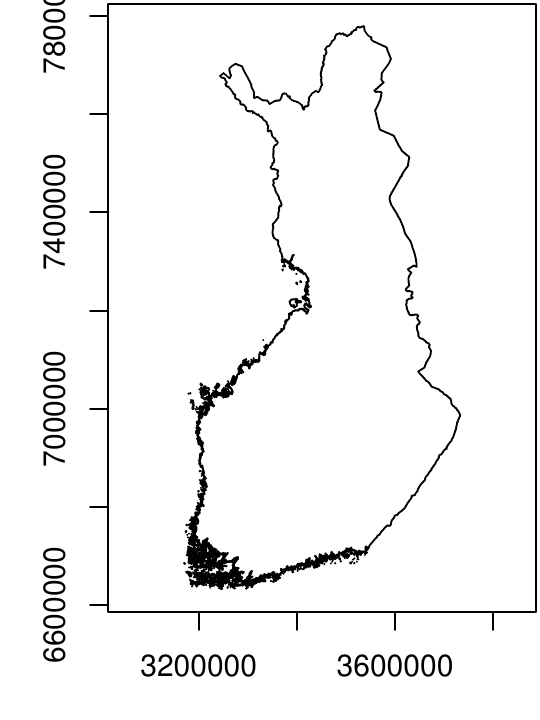

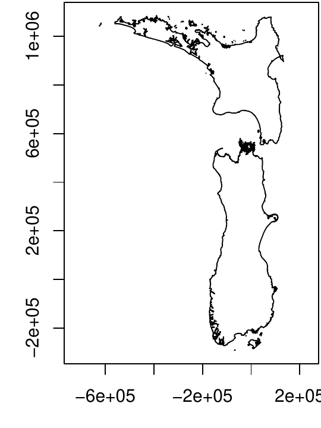

1. Finland, Longitude-Latitude
2. New Zealand, Longitude-Latitude
3. Finland Transverse Mercator
4. New Zealand, Oblique Mercator

Figure 1: Basic maps of Finland and New Zealand in different Coordinate Reference Systems.

Cylindrical map projections can be constructed from any cylinder containing the Earth, and there is no mathematical requirement to use one of the standard transverse Mercator projections with an EPSG number. For example, a given user might consider the point $(170^\circ\text{E}, 45^\circ\text{S})$ to be an intuitive location for the origin of the transformed map of New Zealand, and thus decide to define a custom CRS with this centre. The cylinder can follow any Great Circle, it need not be a meridian line, and a Great Circle angled $40^\circ$ clockwise would run the length of the two islands. Cylindrical projections with an angle are termed Oblique Mercator projections (see Snyder 1987 66), and can be constructed with the assistance of *mapmisc*’s `omerc` function. A custom projection with the $(170^\circ\text{E}, 45^\circ\text{S})$ origin and a $40^\circ$ rotation is obtained by

```r
nzCrs <- omerc(c(170, -45), angle = 40)
nzCrs
```

```r
## CRS arguments:
##  +proj=omerc +lat_0=-45 +lonc=170 +alpha=40 +k=1 +x_0=0 +y_0=0 +gamma=0
## +ellps=WGS84 +units=m
```

The difference between the above and the projection for Finland is the `omerc` in place of `tmerc`, with the additional argument `+alpha=40` specifying an angle. The New Zealand coastline can be projected to this CRS with `spTransform`.

```r
nzRot <- spTransform(nzClip, nzCrs)
```

Figure 1d results from executing `plot(nzRot, axes = TRUE)`, and New Zealand has been rotated $40^\circ$ to a vertical position.

### 2.2 Finding a projection

When choosing a map projection for a dataset, a simple web search of a phrase such as “map projection finland epsg” will often give clear advice as to what the most commonly used national CRS is. A number of tools in *rgdal* can be used to obtain a projection in a more systematic manner. Below the `make_EPSG` function creates a table of all EPSG coded CRS’s which *rgdal* supports, and a `grep` command used to show all those projections with “Finland” in its description. The resulting list of projections below confirms that 2393 is a sensible choice.

```r
allEpsg <- rgdal::make_EPSG()
allEpsg[grep("Finland", allEpsg$note), 1:2]
```

```r
##      code                                                   note
## 859  2391                                 # KKJ / Finland zone 1
## 860  2392                                 # KKJ / Finland zone 2
## 861  2393              # KKJ / Finland Uniform Coordinate System
## 862  2394                                 # KKJ / Finland zone 4
## 1853 3386                                 # KKJ / Finland zone 0
## 1854 3387                                 # KKJ / Finland zone 5
## 4929 3901 # KKJ / Finland Uniform Coordinate System + N60 height
```

A second method for obtaining a CRS is to make a rough guess at a projection string and use `showEPSG` to attempt to find a corresponding EPSG code. Were one to use a Universal Transverse Mercator (or UTM) projection for a map of Finland, a web search for “UTM zone map” shows that Finland lies in UTM zone 35. A proj4 specification of a UTM zone 35 projection will contain `+proj=utm` and `+zone=35`, and `showEPSG` states that the EPSG code 32635 corresponds to an appropriate CRS.

```r
rgdal::showEPSG("+proj=utm +zone=35")
```

```r
## [1] "32635"
```

```r
CRS("+init=epsg:32635")
```

```r
## CRS arguments:
##  +init=epsg:32635 +proj=utm +zone=35 +datum=WGS84 +units=m +no_defs
## +ellps=WGS84 +towgs84=0,0,0
```

The definitive resource for information on national map projections is contained in the monthly bulletins of [The Imaging and Geospatial Information Society](http://www.asprs.org). The `GridsDatums` data set in *rgdal* gives the year and month for each country’s entry at www.asprs.org/Grids-Datums.html. The [entry for Finland](http://www.asprs.org/wp-content/uploads/2012/05/10-2006-finland.pdf) appears in the October 2006 issue.

```r
data("GridsDatums", package = "rgdal")
GridsDatums[grep("Finland", GridsDatums$country), ]
```

```r
##                 country     month year ISO
## 100 Republic of Finland (October) 2006 FIN
```

### 2.3 Mapping projected data

The *mapmisc* functions `openmap`, `map.new`, `scaleBar`, and `insetMap` can be used together to improve on the basic maps in Figure 1, and they are used here to add background images, a scale bar, and an inset map to Figure 2.

Background map images are obtained from the `openmap` function, which downloads image files from [OpenStreetMap.org](http://openstreetmap.org) or a number of other sources. The images used in Figure 2 were obtained with

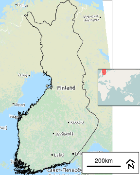

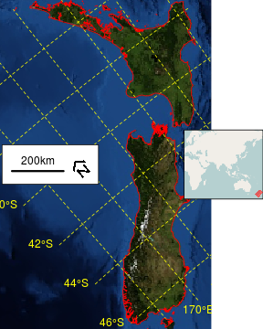

```r
nzBg <- openmap(nzRot, path = "mapquest-sat")
finlandBg <- openmap(finlandMerc, path = "landscape")
```

1. Finland. Background © [OpenStreetMap](http://openstreetmap.org/copyright)
2. New Zealand. Tiles courtesy of [MapQuest](http://www.mapquest.com) and © [OpenStreetMap](http://openstreetmap.org/copyright)

Figure 2: Maps produced using the *mapmisc* package, containing background images, inset maps, and scale bars.

The first argument of `openmap` is used to set both the spatial extent of the map to be retrieved and the CRS the map will be projected to. Any spatial object `x` for which `extent(x)` and `projection(x)` are defined can be provided to `openmap`. The `path =` argument specifies the source of the map, and sample maps from the various sources are shown in Figure 11 in the Appendix. The objects produced by `openmap` are raster objects, converted from image files downloaded from web map servers. The Finland map is an object of class “RasterLayer”.

```r
finlandBg
```

```r
## class       : RasterLayer
## dimensions  : 768, 376, 288768  (nrow, ncol, ncell)
## resolution  : 2747, 2252  (x, y)
## extent      : 2889952, 3922969, 6183827, 7913059  (xmin, xmax, ymin, ymax)
## coord. ref. : +init=epsg:2393 +proj=tmerc +lat_0=0 +lon_0=27 +k=1 +x_0=3500000 +...
## data source : in memory
## names       : landscape
## values      : 1, 1022  (min, max)
```

Notice that the CRS is the same as for the `finlandMerc` object. The New Zealand map is a “RasterStack” with red, green and blue layers.

```r
nzBg
```

```r
## class       : RasterStack
## dimensions  : 512, 289, 147968, 3  (nrow, ncol, ncell, nlayers)
## resolution  : 5237, 5190  (x, y)
## extent      : -1e+06, 510285, -977333, 1680003  (xmin, xmax, ymin, ymax)
## coord. ref. : +proj=omerc +lat_0=-45 +lonc=170 +alpha=40 +k=1 +x_0=0 +y_0=0 +gam...
## names       : mapquest.satRed, mapquest.satGreen, mapquest.satBlue
## min values  :               0,                 0,                0
## max values  :             248,               250,              247
```

The Finland map can be viewed with `plot(finlandBg)`, whereas the three-layered New Zealand map needs the `plotRGB` function for plotting its red, green and blue values as colours.

```r
map.new(finlandMerc, 0.8)
plot(finlandBg, add = TRUE)
plot(finlandMerc, add = TRUE)
scaleBar(finlandMerc, "bottomright")
insetMap(finlandMerc, "right", width = 0.3, cropInset = extent(0, 180, -50, 70))
```

The New Zealand map in Figure 2b is produced with similar code.

```r
map.new(nzRot, 0.8)
plotRGB(nzBg, add = TRUE)
rgdal::llgridlines(nzRot, col = "yellow")
plot(nzRot, add = TRUE, border = "red")
scaleBar(nzRot, "left")
insetMap(nzRot, "right", width = 0.3, cropInset = extent(0, 180, -50, 70))
```

The use of `plotRGB` in place of `plot` is used for the background map, and the scale bar has been placed at the centre-left. The `llgridlines` function from *rgdal* added latitude and meridian lines in yellow.

The images in Figure 2 have dimensions of 4 by 5 inches, saved as `png` files with 72 pixels per inch. Executing the code above in an interactive R session will likely produce maps with a slightly different appearance unless the graphics window has these same dimensions. This document is produced with [*knitr*](https://CRAN.R-project.org/package=knitr) (Xie 2015), and the figure dimensions are set with the `fig.height =` and `fig.width =` options to code chunks.

The map images in `finlandBg` and `nzBg` were retrieved from [OpenStreetMap.org](http://openstreetmap.org) and [MapQuest](http://www.mapquest.com) respectively, and although they are free to use and reproduce they must be attributed. The `openmapAttribution` function produces an attribution for an object produced by `openmap` or a string valid as a `path =` argument for `openmap`. An attribution for `nzBg` (or `"mapquest-sat"`), as in the caption for Figure 2, is produced with

```r
openmapAttribution(nzBg, short = TRUE)
```

```r
##                                   mapquest.sat
## "Tiles courtesy of MapQuest(www.mapquest.com)"
```

The Acknowledgements section of this paper has used this function without the `short = TRUE` argument.

```r
openmapAttribution(finlandBg)
```

```r
##   landscape
## "copyright OpenStreetMap.org contributors. Data by OpenStreetMap.org
 #  available under the Open Database License (opendatacommons.org/licenses/odbl),
 #  cartography by Thunderforest.com"
```

The additional argument `type = "latex"` is used in the source code for this paper, and `type = "markdown"` is also available.

### 2.4 Projecting background maps

There are a number of potential pitfalls involved when using background map images with projected data, and this section will describe some additional options to `openmap` and `map.new` which can help in this regard.

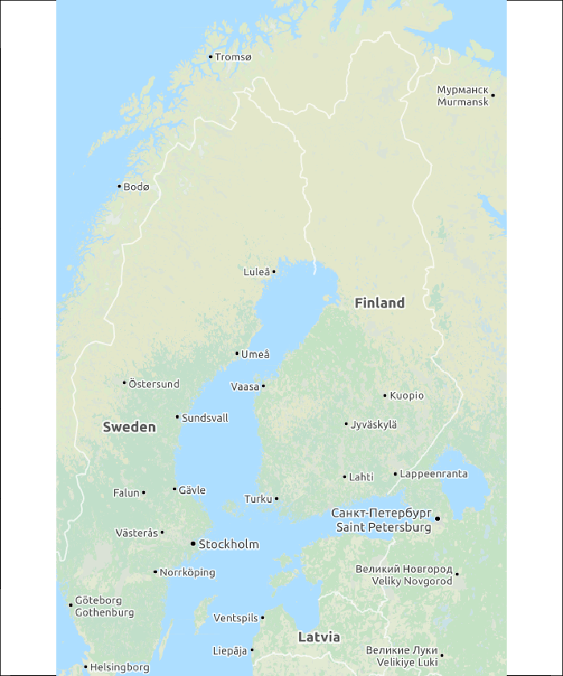

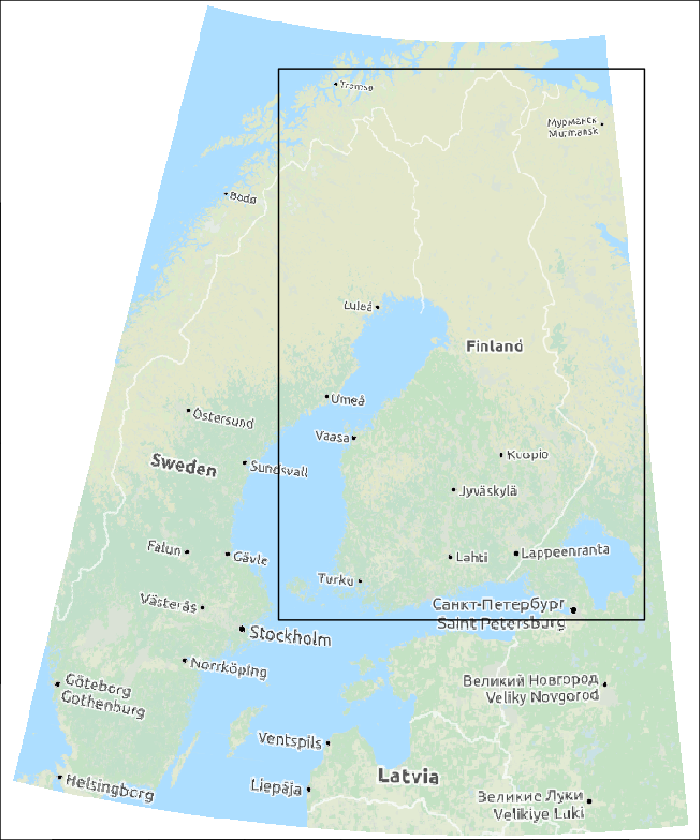

1. Spherical Mercator
2. Finland UCS

Figure 3: Map images of Finland in the Spherical Mercator projection and the Finland Uniform Coordinate System (UCS) projection. © [OpenStreetMap](http://openstreetmap.org/copyright).

The map images provided by [OpenStreetMap.org](http://openstreetmap.org) and elsewhere are available at different zoom levels or resolutions. A map at zoom level 0 is a 256 by 256 pixel image covering the entire world. Zoom level 1 covers the world in 4 “map tiles” of 256 by 256 pixels, and zoom level $N$ consists of $4^N$ such tiles. The zoom level can be specified directly in `openmap` with the `zoom =` argument, or indirectly with the `maxTiles =` argument. With the default value of `maxTiles = 9`, `opemnap` will find the highest zoom level where the number of map tiles required to cover the spatial object supplied is at most 9. The `finlandBg` map has a zoom level of 5 and 6 tiles, giving a 376 by 768 pixel image. This information is contained in an attribute of `finlandBg`.

```r
attributes(finlandBg)$tiles
```

```r
## $tiles
## [1] 6
##
## $zoom
## [1] 5
##
## $path
##                                 landscape
## "http://tile.opencyclemap.org/landscape/"
```

```r
dim(finlandBg)
```

```r
## [1] 768 376   1
```

When `openmap` projects the downloaded map tiles to the Finland CRS (using `projectRaster` from the *raster* package), a number of pixels from the original map are lost or put out of position and the text can become mangled.

A partial solution for improving projected images is best illustrated with the rotated CRS used for New Zealand. Figure 4a shows a map of Auckland, New Zealand, in the Spherical Mercator projection provided by [OpenStreetMap.org](http://openstreetmap.org), and the rotated Oblique Mercator projection used earlier is used for the map in Figure 4b. The map images are obtained by creating a “SpatialPoints” object for the location of Auckland in long-lat coordinates and projecting it to the CRS of the `nzRot` object from Figure 2b.

```r
aucklandLL <- SpatialPoints(data.frame(x = 174.764204, y = -36.853744),
    proj4string = crsLL)
auckland <- spTransform(aucklandLL, projection(nzRot))
```

`crsLL` is an object in *mapmisc* specifying the WGS84 projection, identical to `CRS("+init=epsg:4326)`. The map in Figure 4b is retrieved below.

```r
aucklandBg <- openmap(auckland, buffer = 3000, maxTiles = 4)
```

The `buffer =` argument specifies an additional area around `auckland` which the map should cover (in this case 3km), and specifying `maxTiles = 4` will select the highest zoom level which is able to cover the map region with four or fewer tiles. A map at the same zoom level in the Spherical Mercator projection, for Figure 4a, is obtained next.

```r
aucklandBgMerc <- openmap(auckland, zoom = attributes(aucklandBg)$tiles$zoom,
    path = attributes(aucklandBg)$tiles$path, crs = crsMerc)
```

The `crsMerc` object gives the Spherical Mercator projection.

```r
crsMerc
```

```r
## CRS arguments:
##  +proj=merc +a=6378137 +b=6378137 +lat_ts=0.0 +lon_0=0.0 +x_0=0.0 +y_0=0
## +k=1.0 +units=m +no_defs
```

Figure 4c shows only the area within 3km of the `auckland` object, produced by adding the `buffer = 3000` argument to `map.new`.

```r
map.new(auckland, buffer = 3000)
plot(aucklandBg, add = TRUE)
scaleBar(auckland, "topleft")
```

```r
aucklandFine <- openmap(auckland, buffer = 3000,
    zoom = attributes(aucklandBg)$tiles$zoom, fact = 4)
map.new(auckland, buffer = 3000)
plot(aucklandFine, add = TRUE)
scaleBar(auckland, "topleft")
```

Re-projecting rasters is computationally intensive, and `openmap` can require considerable running time when the zoom level or `fact` argument are large.

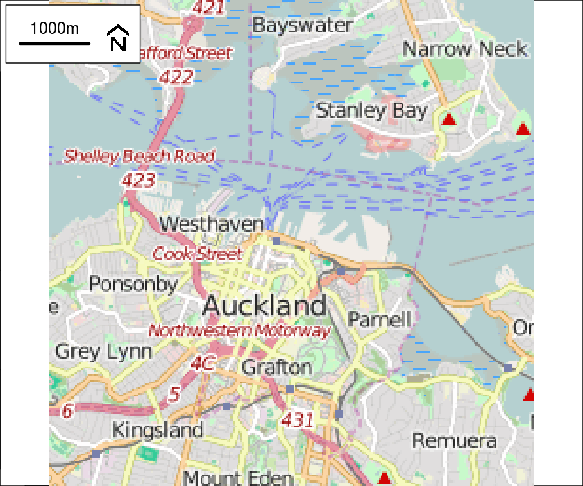

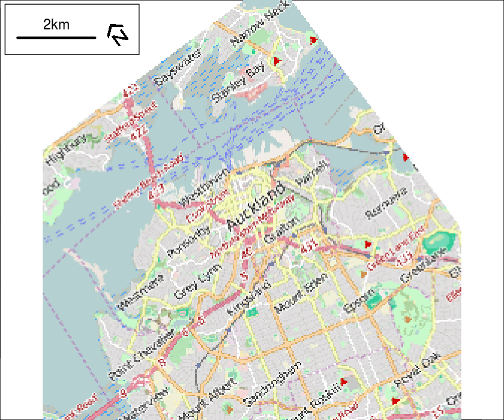

1. Spherical Mercator
2. Oblique Mercator

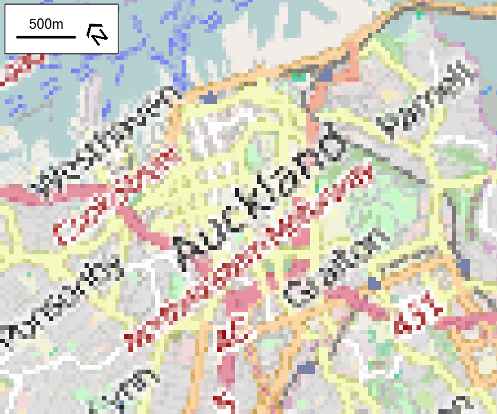

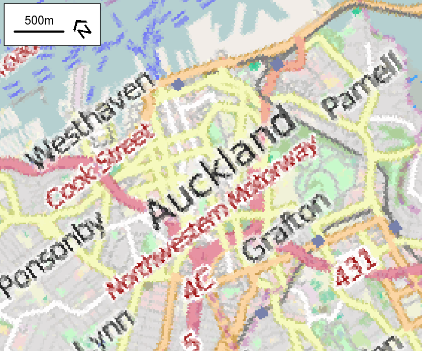

3. Oblique, detail
4. Oblique, high resolution

Figure 4: Map images of Auckland, NZ, in Spherical Mercator and Oblique Mercator projections. © [OpenStreetMap](http://openstreetmap.org/copyright).

### 2.5 Equal-area map projections

This section covers producing maps of the entire globe using the functions `moll`, `wrapPoly`, and `gridlinesWrap`. A number of different Coordinate Reference Systems (CRS’s) are used to display maps of the world, and Munroe (2011) is a useful introduction to some of the most popular of these. Figure 5a shows the world in a Mollweide projection (Wikipedia 2015b), an equal-area CRS with the property that the sizes of polygons on the map are roughly proportional to their true surface areas. Figures 5b, 5e and 5f use Mollweide projections with different origins and angles of orientation, projections which are obtainable with *mapmisc*.

Polygons corresponding to the borders of the countries of the world are contained in the `wrld_simpl` object from the *maptools* package, and this object will be used to produce the images in Figure 5. The object is loaded with

```r
data("wrld_simpl", package = "maptools")
wrld_simpl
```

```r
## class       : SpatialPolygonsDataFrame
## features    : 246
## extent      : -180, 180, -90, 83.6  (xmin, xmax, ymin, ymax)
## coord. ref. : +proj=longlat +ellps=WGS84 +datum=WGS84 +no_defs +towgs84=0,0,0
## variables   : 11
## names       : FIPS, ISO2, ISO3,  UN,           NAME,    AREA,  POP2005, REGION, ...
## min values  :     ,   AD,  ABW,  10, Aaland Islands,       0, 0.00e+00,      0, ...
## max values  :   ZI,   ZW,  ZWE,  96,       Zimbabwe,   99545, 9.94e+04,      9, ...
```

and a selection of R’s named colours is assigned to the countries as follows.

```r
colVec <- grep("gray|white|snow|ivory|turquoise|blue|[1-3]", colours(distinct = TRUE),
    invert = TRUE, value = TRUE)
wrld_simpl$col <- rep_len(colVec, length(wrld_simpl))
```

The `moll` function creates “CRS” objects for Mollweide projections, which can be used with `spTransform` to compute a Mollweide projection of `wrld_simpl`.

```r
mollCrs <- moll()
worldMoll <- spTransform(wrld_simpl, mollCrs)
```

This “CRS” object is specified with a string similar to those seen earlier, with `+proj=moll` being the defining feature.

```r
mollCrs
```

```r
## CRS arguments:
##  +proj=moll +lon_wrap=0 +lon_0=0 +x_0=0 +y_0=0 +ellps=WGS84 +datum=WGS84
## +units=m +no_defs +towgs84=0,0,0
```

The `moll` function adds two additional attributes to the “CRS” object produced, one of which is the “ellipse” object containing the spatial extent of the Earth in this projection.

```r
names(attributes(mollCrs))
```

```r
## [1] "projargs" "class"    "crop"     "ellipse"
```

The `map.new` function uses the “ellipse” attribute to define the plotting region and add the light blue background in Figure 5a.

```r
map.new(mollCrs, col = "lightblue")
plot(worldMoll, add = TRUE, col = worldMoll$col,
    border = col2html("black", opacity = 0.2))
gridlinesWrap(worldMoll, lty = 2, col = "red")
```

```r
(mollHawaii <- moll(geocode("hawaii")))
```

```r
## CRS arguments:
##  +proj=moll +lon_wrap=-155.5827818 +lon_0=-155.5827818 +x_0=0 +y_0=0
## +ellps=WGS84 +datum=WGS84 +units=m +no_defs +towgs84=0,0,0
```

A difficulty with this Hawaiian Mollweide projection is that the meridian line along which the world is split runs through many of the polygons in `wrld_simpl`. The `spTransform` function used with this projection produces the polygons in Figure 5c, with horizontal lines connecting the two halves of polygons which have been split. The `wrapPoly` function in *mapmisc* addresses this problem by splitting the affected polygons prior to their projection, using the “crop” attribute of the “CRS” object produced by `moll`.

```r
worldHawaii <- wrapPoly(wrld_simpl, mollHawaii)
```

The red vertical line in Figure 5d is produced from `attributes(mollHawaii)$crop`, and the function `gDifference` from *rgeos* is called by `wrapPoly` to remove the portion of each polygon intersecting with this line.

A Mollweide projection need not have a north-south orientation, and an Oblique Mollweide projection can be constructed by rotating the globe’s long-lat coordinates to produce different origins and orientations. Figure 5e positions Jerusalem at the centre of the Earth (standard practice for cartographers during the middle ages), and at Jerusalem the “up” direction is $35^\circ$ clockwise of north.

```r
(mollOblique <- moll(geocode("jerusalem"), angle = 35))
```

```r
## CRS arguments:
##  +proj=ob_tran +o_proj=moll +o_lon_p=-42.7134520141079
## +o_lat_p=44.2305998589378 +lon_0=-17.7121046024056
## +lon_wrap=-17.7121046024056 +ellps=WGS84 +datum=WGS84 +units=m +no_defs
## +towgs84=0,0,0
```

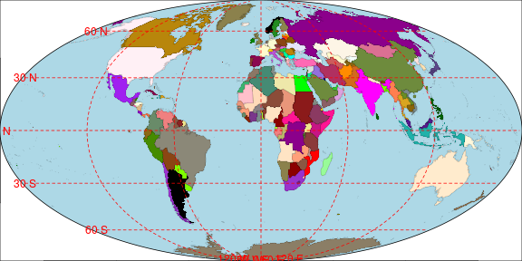

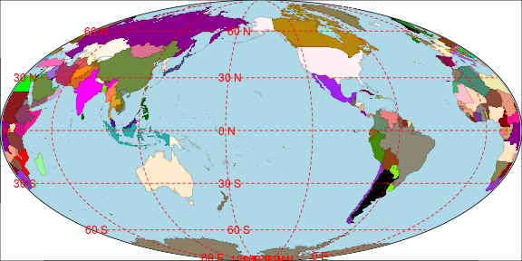

1. Mollweide, Greenwich
2. Mollweide, Hawaii

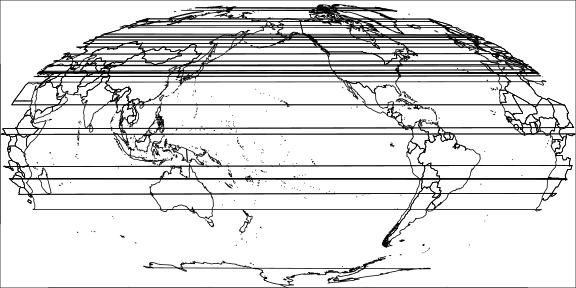

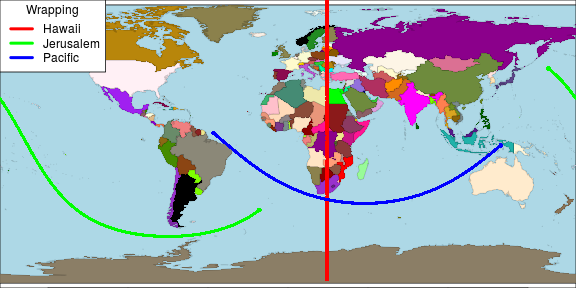

3. Hawaii with `spTransform`
4. Long-Lat

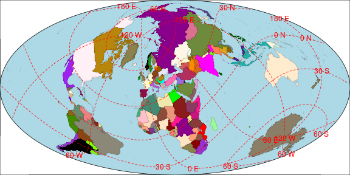

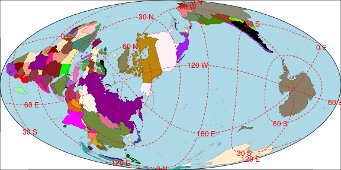

5. Oblique Mollweide, Jerusalem
6. Oblique Mollweide, Pacific

Figure 5: World maps in Mollweide projections.

This string specifies two projections are to be applied. First, `+proj=ob_tran` rotates the long-lat coordinates to move the north pole to the coordinate ($44^\circ$N, $42^\circ$W). Second, `+o_proj=moll` applies a Mollweide projection to these rotated coordinates using $17.7^\circ$W as the central meridian line. These three values ($44^\circ$N, $42^\circ$W, $17.7^\circ$W) are obtained by numerical optimisation, attempting to move Jerusalem as close as possible to the origin while preserving the $35^\circ$ orientation.

Figure 5e is produced by first re-projecting the world map with `wrapPoly`.

```r
worldOblique <- wrapPoly(wrld_simpl, mollOblique)
```

Adding red longitude and latitude grid lines with this projection cannot be done with the `llgridlines` function from *rgdal*, as the same horizontal striping seen in Figure 5c will result. The `gridlinesWrap` function from *mapmisc* breaks the grid lines in the same manner as `wrapPoly`, and adds the red graticule lines as follows.

```r
map.new(mollOblique, col = "lightblue")
plot(worldOblique, add = TRUE, col = worldOblique$col,
    border = col2html("black", 0.2))
gridlinesWrap(worldOblique, lty = 2, col = "red")
```

Figure 5f uses an Oblique Mollweide centred in the Pacific ocean with a $85^\circ$ angle of rotation.

```r
crsN <- moll(c(-140, 40), angle = 85)
```

Unlike the red line of the Hawaiian projection in Figure 5d, the green and blue curves showing where the globe is wrapped for the two Oblique Mollweide projections lie in the ocean for the most part.

Table 1: Surface areas (in millions of km$^2$) of Canada and Congo, and areas computed for country polygons in the Spherical Mercator projection and four Mollweide projections. Columns refer to the standard Mollweide projection (Greenwich) and the Mollweide centred on Hawaii, Jerusalem, and the north Pacific from Figures 5a, 5b, 5e and 5f.

|  | Truth | Spherical Mercator | Greenwich | Hawaii | Jerusalem | Pacific |
| --- | --- | --- | --- | --- | --- | --- |
| Canada | 9.98 | 49.72 | 9.74 | 9.79 | 9.61 | 9.66 |
| Congo | 2.35 | 2.36 | 2.34 | 1.95 | 2.34 | 2.34 |
| ratio | 4.26 | 21.08 | 4.17 | 5.03 | 4.11 | 4.13 |

### 2.6 Custom-optimised Oblique Mercator projections

This section describes the use of the `omerc` function for defining Oblique Mercator projections. Two methods of optimising map projections are implemented, with the angle of rotation chosen to produce the most compact bounding box possible or to preserve distances between a collection of points.

#### Ad-hoc projections for compact plotting regions

Compact representations minimising the number of void cells (i.e. those falling in the ocean) offer computational advantages when used with statistical models or software requiring data on a grid, such as the Markov random field based methods used in Brown (2015). Figure 6 shows New Zealand rotated in order to produce a compact plotting area, with bounding box having the greatest possible proportion of its area made up of land mass. This projection also minimises the number of vertical inches which Figure 6 takes up on the page, which is the reason a clockwise rotation is used in place of the anti-clockwise rotation from Figure 2b.

The `omerc` function calculates these ad-hoc projections based on the object to be re-projected and a vector of rotation angles. The first argument below is the `nzClip` object containing the cropped boundary of New Zealand, and the origin of the Oblique Mercator projection will be its centroid. A sequence of Oblique Mercator projections using Great Circles angled between 10 and 50 degrees from the north will be formulated, and the bounding box of New Zealand in each projection will be computed. The projection returned by `omerc` uses the angle giving the smallest such box, with the argument `+alpha=` showing an $18.5^\circ$ angle in this example.

```r
(nzRotOptCrs <- omerc(nzClip, seq(10, 50, by = 0.5), post = "wide"))
```

```r
## CRS arguments:
##  +proj=omerc +lat_0=-40.565 +lonc=172.502 +alpha=18.5 +k=1 +x_0=0 +y_0=0
## +gamma=90 +ellps=WGS84 +units=m
```

A positive angle rotates the coordinate axes clockwise, which gives the resulting map the appearance of being rotated anti-clockwise. An Oblique Mercator’s Great Circle becomes the $y$-axis of the coordinate system, and a projection should seek to have as much of the area of interest as possible being close to this Great Circle. An optimal projection will therefore have a tall and narrow bounding box, in this instance the spine of New Zealand should run up and down the $y$-axis. The limits of 10 and 50 for the sequence of angles above are arbitrary estimates of the amount of anti-clockwise rotation required to sit New Zealand upright. The argument `post = "wide"` in `omerc` specifies that a short and wide bounding box is required, and this is accomplished by rotating the planar $x$-$y$ coordinates post-projection using the `+gamma=90` element.

New Zealand is re-projected and a new background map in this projection is produced below.

```r
nzRotOpt <- spTransform(nzClip, nzRotOptCrs)
nzBgRot <- openmap(nzRotOpt, path = "cartodb", buffer = 20000, fact = 2)
```

Figure 6 is produced with the following.

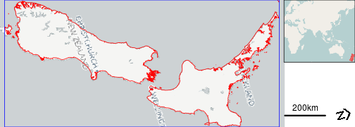

Figure 6: New Zealand in a $18.5^\circ$ Oblique Mercator projection ( **—** ) with bounding box ( **—** ). Background © [CartoDB](http://cartodb.com), © [OpenStreetMap](http://openstreetmap.org/copyright).

```r
map.new(nzRotOpt, 0.8)
plot(nzBgRot, add = TRUE)
plot(nzRotOpt, add = TRUE, border = "red")
plot(extent(nzRotOpt), add = TRUE, col = "blue")
scaleBar(nzRotOpt, "bottomright", bty = "n")
insetMap(nzRotOpt, "topright", cropInset = extent(0, 180, -50, 70), width = 0.2)
```